# Inside New York's restaurant inspections, in plain SQL

**163,000 inspection records covering 26,000 restaurants (January 2025 onwards)** from the city's health department, analysed with SQL only. The table has one row per violation, so the first step of most queries is a CTE that collapses it to one row per inspection. Then: grade shares by borough, the most common violations, medians per cuisine built from `ROW_NUMBER` windows, monthly trends with `LAG`, chain rankings from both ends with two `ROW_NUMBER`s, closure rates, and what happens at the next inspection after a bad one (`LEAD`). Python only runs the queries and draws the charts.

**Data:** [DOHMH New York City Restaurant Inspection Results](https://data.cityofnewyork.us/Health/DOHMH-New-York-City-Restaurant-Inspection-Results/43nn-pn8j) from NYC Open Data. Run `python build_db.py` once to download everything since 1 January 2025 (about 33 MB) into a SQLite database, then point `RESTAURANTS_DB` at that file.

**Reading the data.** A lower score is better: 0-13 earns an A, 14-27 a B and 28 or more a C. Not every inspection gets a letter (grades are given after the initial inspection or a re-inspection, and a restaurant can be left "pending"), so grade shares use inspections that did receive an A, B or C. Rows with a missing borough are left out of the borough comparison.

```python
import os
import sqlite3
from pathlib import Path

import matplotlib.pyplot as plt
import numpy as np
import pandas as pd

DB_PATH = Path(os.environ.get("RESTAURANTS_DB", "restaurants.db"))
AMBER, BLUE, GREY = "#e8a33d", "#2b6cb0", "#a0aec0"
plt.rcParams.update({"axes.spines.top": False, "axes.spines.right": False, "axes.grid": True,
                     "grid.alpha": 0.25, "figure.dpi": 110})
pd.set_option("display.width", 120)
pd.set_option("display.max_columns", 20)

con = sqlite3.connect(DB_PATH)


def q(sql):
    """Run a query and return the result as a DataFrame."""
    return pd.read_sql_query(sql, con)
```

## 0. What is in the database?

```python
tables = q("SELECT name FROM sqlite_master WHERE type = 'table' ORDER BY name").name
pd.DataFrame({"table": tables,
              "rows": [con.execute(f'SELECT COUNT(*) FROM "{t}"').fetchone()[0] for t in tables]})
```

|  | table | rows |
| --- | --- | --- |
| 0 | inspections | 163406 |
| 1 | violation_codes | 148 |

## 1. How do the boroughs compare on grades?

First a CTE reduces the table to one row per inspection. Then conditional aggregation counts A, B and C grades per borough and the shares come straight from averaging 0/1 flags (`AVG(grade = 'A')`).

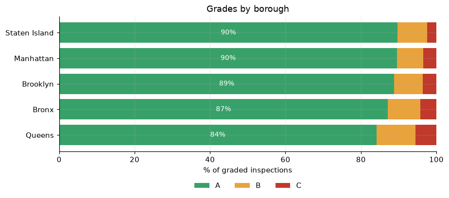

|  | borough | graded_inspections | a_pct | b_pct | c_pct | avg_score |
| --- | --- | --- | --- | --- | --- | --- |
| 0 | Staten Island | 843 | 89.7 | 7.8 | 2.5 | 11.0 |
| 1 | Manhattan | 10168 | 89.6 | 6.9 | 3.5 | 11.4 |
| 2 | Brooklyn | 6841 | 88.8 | 7.6 | 3.6 | 11.3 |
| 3 | Bronx | 2612 | 87.1 | 8.7 | 4.2 | 12.0 |
| 4 | Queens | 6397 | 84.1 | 10.3 | 5.6 | 12.7 |

```python
grades = q("""
WITH insp AS (
    SELECT camis, inspection_date,
           MAX(dba)                          AS name,
           MAX(boro)                         AS boro,
           MAX(cuisine_description)          AS cuisine,
           MAX(inspection_type)              AS inspection_type,
           MAX(score)                        AS score,
           MAX(grade)                        AS grade,
           MAX(action)                       AS action,
           COUNT(violation_code)             AS violations,
           SUM(critical_flag = 'Critical')   AS critical_violations
    FROM inspections
    GROUP BY camis, inspection_date
)
SELECT boro                                              AS borough,
       COUNT(*)                                          AS graded_inspections,
       ROUND(100.0 * AVG(grade = 'A'), 1)                AS a_pct,
       ROUND(100.0 * AVG(grade = 'B'), 1)                AS b_pct,
       ROUND(100.0 * AVG(grade = 'C'), 1)                AS c_pct,
       ROUND(AVG(score), 1)                              AS avg_score
FROM insp
WHERE grade IN ('A', 'B', 'C') AND boro <> '0'
GROUP BY boro
ORDER BY a_pct DESC
""")

fig, ax = plt.subplots(figsize=(8.5, 3.9))
ax.barh(grades.borough[::-1], grades.a_pct[::-1], color="#38a169", label="A")
ax.barh(grades.borough[::-1], grades.b_pct[::-1], left=grades.a_pct[::-1], color=AMBER, label="B")
ax.barh(grades.borough[::-1], grades.c_pct[::-1], left=(grades.a_pct + grades.b_pct)[::-1], color="#c0392b", label="C")
for y, a in enumerate(grades.a_pct[::-1]):
    ax.text(a / 2, y, f"{a:.0f}%", ha="center", va="center", color="white", fontsize=9)
ax.set_xlim(0, 100)
ax.set_xlabel("% of graded inspections")
ax.set_title("Grades by borough")
ax.legend(frameon=False, ncol=3, loc="upper center", bbox_to_anchor=(0.5, -0.18))
fig.tight_layout()
plt.show()
grades
```

## 2. What do inspectors find most often?

Each violation code is counted once per inspection (`COUNT(DISTINCT ...)`) and divided by the total number of inspections from a scalar subquery. The lookup table supplies the description (shortened here).

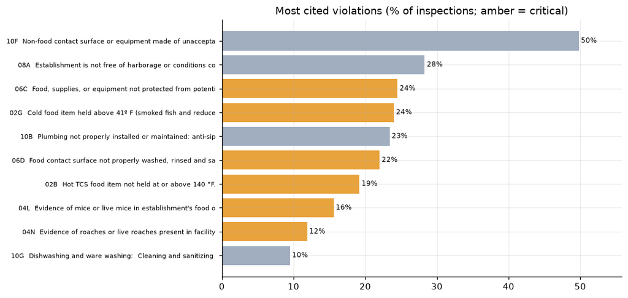

|  | code | type | inspections |
| --- | --- | --- | --- |
| 0 | 10F | Not Critical | 22910 |
| 1 | 08A | Not Critical | 13014 |
| 2 | 06C | Critical | 11283 |
| 3 | 02G | Critical | 11033 |
| 4 | 10B | Not Critical | 10739 |
| 5 | 06D | Critical | 10122 |
| 6 | 02B | Critical | 8845 |
| 7 | 04L | Critical | 7153 |
| 8 | 04N | Critical | 5482 |
| 9 | 10G | Not Critical | 4346 |

```python
violations = q("""
SELECT v.violation_code                                          AS code,
       substr(c.violation_description, 1, 80)                    AS description,
       MAX(v.critical_flag)                                      AS type,
       COUNT(DISTINCT v.camis || v.inspection_date)              AS inspections,
       ROUND(100.0 * COUNT(DISTINCT v.camis || v.inspection_date)
             / (SELECT COUNT(DISTINCT camis || inspection_date) FROM inspections), 1) AS pct_of_inspections
FROM inspections v
JOIN violation_codes c USING (violation_code)
GROUP BY v.violation_code
ORDER BY inspections DESC
LIMIT 10
""")

fig, ax = plt.subplots(figsize=(10, 4.8))
labels = violations.code + "  " + violations.description.str.slice(0, 55)
ax.barh(labels[::-1], violations.pct_of_inspections[::-1],
        color=[AMBER if t == "Critical" else GREY for t in violations.type[::-1]])
for y, v in enumerate(violations.pct_of_inspections[::-1]):
    ax.text(v + 0.3, y, f"{v:.0f}%", va="center", fontsize=8)
ax.set_xlim(0, violations.pct_of_inspections.max() * 1.12)
ax.set_title("Most cited violations (% of inspections; amber = critical)")
ax.tick_params(axis="y", labelsize=7)
fig.tight_layout()
plt.show()
violations[["code", "type", "inspections"]]
```

## 3. Which cuisines score best and worst?

SQLite has no `MEDIAN`, so it is built from a window: `ROW_NUMBER()` orders each cuisine's inspections by score and `COUNT(*) OVER` gives the group size, so the row half-way down is the median. Only cuisines with 400 or more scored inspections are included.

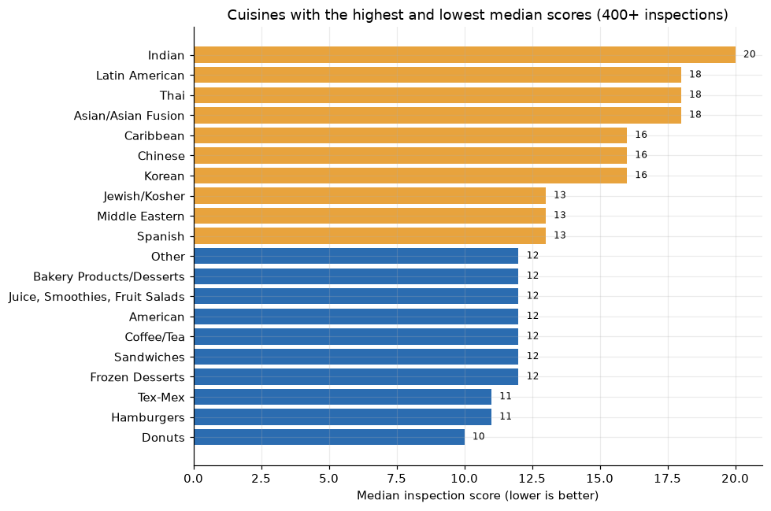

```
(28, 5)
```

```python
cuisines = q("""
WITH insp AS (
    SELECT camis, inspection_date,
           MAX(dba)                          AS name,
           MAX(boro)                         AS boro,
           MAX(cuisine_description)          AS cuisine,
           MAX(inspection_type)              AS inspection_type,
           MAX(score)                        AS score,
           MAX(grade)                        AS grade,
           MAX(action)                       AS action,
           COUNT(violation_code)             AS violations,
           SUM(critical_flag = 'Critical')   AS critical_violations
    FROM inspections
    GROUP BY camis, inspection_date
),
scored AS (
    SELECT cuisine, score, critical_violations
    FROM insp
    WHERE score IS NOT NULL AND cuisine IS NOT NULL
),
ranked AS (
    SELECT *,
           ROW_NUMBER() OVER (PARTITION BY cuisine ORDER BY score) AS rn,
           COUNT(*)     OVER (PARTITION BY cuisine)                AS n
    FROM scored
)
SELECT cuisine,
       MAX(n)                                                        AS inspections,
       MAX(CASE WHEN rn = (n + 1) / 2 THEN score END)                AS median_score,
       ROUND(AVG(score), 1)                                          AS avg_score,
       ROUND(AVG(critical_violations), 1)                            AS avg_critical_violations
FROM ranked
GROUP BY cuisine
HAVING inspections >= 400
ORDER BY median_score DESC, avg_score DESC
""")

d = pd.concat([cuisines.head(10), cuisines.tail(10)])
fig, ax = plt.subplots(figsize=(9, 6))
colors = [AMBER] * 10 + [BLUE] * 10
ax.barh(d.cuisine[::-1], d.median_score[::-1], color=colors[::-1])
for y, v in enumerate(d.median_score[::-1]):
    ax.text(v + 0.3, y, f"{v:g}", va="center", fontsize=8)
ax.set_xlabel("Median inspection score (lower is better)")
ax.set_title("Cuisines with the highest and lowest median scores (400+ inspections)")
fig.tight_layout()
plt.show()
cuisines.shape
```

## 4. Is the picture changing month by month?

Monthly inspection counts and average scores for cycle inspections, with `LAG()` giving the change in the average score from the previous month.

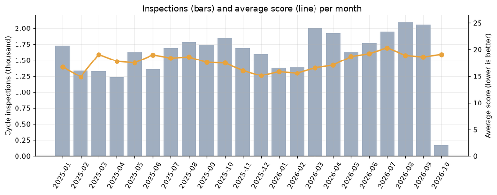

|  | month | inspections | avg_score | a_grade_pct | change_vs_prev_month |
| --- | --- | --- | --- | --- | --- |
| 16 | 2026-05 | 1622 | 18.7 | 83.3 | 1.6 |
| 17 | 2026-06 | 1772 | 19.2 | 78.8 | 0.5 |
| 18 | 2026-07 | 1942 | 20.3 | 78.6 | 1.1 |
| 19 | 2026-08 | 2094 | 18.9 | 81.5 | -1.4 |
| 20 | 2026-09 | 2057 | 18.6 | 79.3 | -0.3 |
| 21 | 2026-10 | 174 | 19.1 | 77.5 | 0.5 |

```python
monthly = q("""
WITH insp AS (
    SELECT camis, inspection_date,
           MAX(dba)                          AS name,
           MAX(boro)                         AS boro,
           MAX(cuisine_description)          AS cuisine,
           MAX(inspection_type)              AS inspection_type,
           MAX(score)                        AS score,
           MAX(grade)                        AS grade,
           MAX(action)                       AS action,
           COUNT(violation_code)             AS violations,
           SUM(critical_flag = 'Critical')   AS critical_violations
    FROM inspections
    GROUP BY camis, inspection_date
),
monthly AS (
    SELECT substr(inspection_date, 1, 7)           AS month,
           COUNT(*)                                AS inspections,
           ROUND(AVG(score), 1)                    AS avg_score,
           ROUND(100.0 * AVG(grade = 'A'), 1)      AS a_grade_pct
    FROM insp
    WHERE inspection_type LIKE 'Cycle Inspection%' AND score IS NOT NULL
    GROUP BY month
)
SELECT month, inspections, avg_score, a_grade_pct,
       ROUND(avg_score - LAG(avg_score) OVER (ORDER BY month), 1) AS change_vs_prev_month
FROM monthly
ORDER BY month
""")

fig, ax = plt.subplots(figsize=(10, 4))
ax.bar(monthly.month, monthly.inspections / 1000, color=GREY)
ax.set_ylabel("Cycle inspections (thousand)")
ax.tick_params(axis="x", rotation=60)
ax2 = ax.twinx()
ax2.plot(monthly.month, monthly.avg_score, color=AMBER, marker="o", lw=2)
ax2.set_ylabel("Average score (lower is better)")
ax2.set_ylim(0, monthly.avg_score.max() * 1.3)
ax2.grid(False)
ax2.spines["right"].set_visible(True)
ax.set_title("Inspections (bars) and average score (line) per month")
fig.tight_layout()
plt.show()
monthly.tail(6)
```

## 5. Which chains have the cleanest and the dirtiest records?

Restaurants are grouped by trading name, and only names with at least 15 locations count as chains. Two `ROW_NUMBER`s, one ascending and one descending by average score, let a single `WHERE` pick the best and the worst eight from the same ranked table.

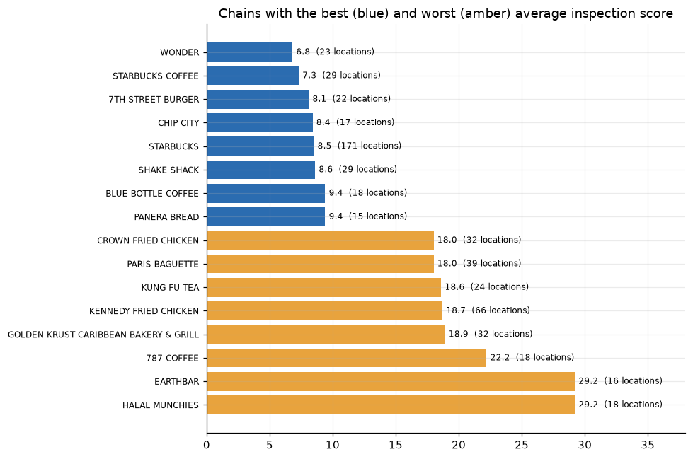

|  | group_ | name | locations | inspections | avg_score | a_grade_pct |
| --- | --- | --- | --- | --- | --- | --- |
| 0 | Best | WONDER | 23 | 30 | 6.8 | 100.0 |
| 1 | Best | STARBUCKS COFFEE | 29 | 41 | 7.3 | 100.0 |
| 2 | Best | 7TH STREET BURGER | 22 | 28 | 8.1 | 100.0 |
| 3 | Best | CHIP CITY | 17 | 22 | 8.4 | 95.0 |
| 4 | Best | STARBUCKS | 171 | 286 | 8.5 | 98.9 |
| 5 | Best | SHAKE SHACK | 29 | 41 | 8.6 | 97.1 |
| 6 | Best | BLUE BOTTLE COFFEE | 18 | 29 | 9.4 | 95.8 |
| 7 | Best | PANERA BREAD | 15 | 24 | 9.4 | 100.0 |
| 8 | Worst | CROWN FRIED CHICKEN | 32 | 71 | 18.0 | 77.1 |
| 9 | Worst | PARIS BAGUETTE | 39 | 83 | 18.0 | 87.5 |
| 10 | Worst | KUNG FU TEA | 24 | 40 | 18.6 | 79.3 |
| 11 | Worst | KENNEDY FRIED CHICKEN | 66 | 127 | 18.7 | 76.1 |
| 12 | Worst | GOLDEN KRUST CARIBBEAN BAKERY & GRILL | 32 | 87 | 18.9 | 86.5 |
| 13 | Worst | 787 COFFEE | 18 | 51 | 22.2 | 64.3 |
| 14 | Worst | EARTHBAR | 16 | 26 | 29.2 | 50.0 |
| 15 | Worst | HALAL MUNCHIES | 18 | 41 | 29.2 | 50.0 |

```python
chains = q("""
WITH insp AS (
    SELECT camis, inspection_date,
           MAX(dba)                          AS name,
           MAX(boro)                         AS boro,
           MAX(cuisine_description)          AS cuisine,
           MAX(inspection_type)              AS inspection_type,
           MAX(score)                        AS score,
           MAX(grade)                        AS grade,
           MAX(action)                       AS action,
           COUNT(violation_code)             AS violations,
           SUM(critical_flag = 'Critical')   AS critical_violations
    FROM inspections
    GROUP BY camis, inspection_date
),
chains AS (
    SELECT name,
           COUNT(DISTINCT camis)                   AS locations,
           COUNT(*)                                AS inspections,
           ROUND(AVG(score), 1)                    AS avg_score,
           ROUND(100.0 * AVG(grade = 'A'), 1)      AS a_grade_pct
    FROM insp
    WHERE score IS NOT NULL
    GROUP BY name
    HAVING locations >= 15
),
ranked AS (
    SELECT *,
           ROW_NUMBER() OVER (ORDER BY avg_score)      AS best_rank,
           ROW_NUMBER() OVER (ORDER BY avg_score DESC) AS worst_rank
    FROM chains
)
SELECT CASE WHEN best_rank <= 8 THEN 'Best' ELSE 'Worst' END AS group_,
       name, locations, inspections, avg_score, a_grade_pct
FROM ranked
WHERE best_rank <= 8 OR worst_rank <= 8
ORDER BY avg_score
""")

fig, ax = plt.subplots(figsize=(9, 6))
ax.barh(chains.name[::-1], chains.avg_score[::-1], color=[AMBER if g == "Worst" else BLUE for g in chains.group_[::-1]])
for y, (v, n) in enumerate(zip(chains.avg_score[::-1], chains.locations[::-1])):
    ax.text(v + 0.3, y, f"{v:.1f}  ({n} locations)", va="center", fontsize=8)
ax.set_xlim(0, chains.avg_score.max() * 1.3)
ax.set_title("Chains with the best (blue) and worst (amber) average inspection score")
ax.tick_params(axis="y", labelsize=8)
fig.tight_layout()
plt.show()
chains
```

## 6. Which cuisines get closed most often?

An inspection ends in a closure when its action text starts with 'Establishment Closed'. Averaging that 0/1 flag per cuisine gives the closure rate (cuisines with at least 600 inspections).

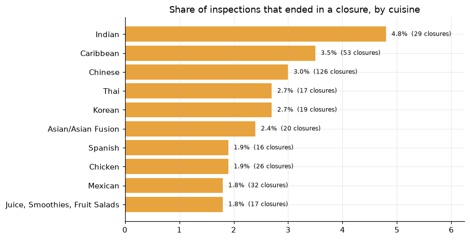

|  | cuisine | inspections | closures | closure_pct |
| --- | --- | --- | --- | --- |
| 0 | Indian | 603 | 29 | 4.8 |
| 1 | Caribbean | 1522 | 53 | 3.5 |
| 2 | Chinese | 4178 | 126 | 3.0 |
| 3 | Thai | 631 | 17 | 2.7 |
| 4 | Korean | 715 | 19 | 2.7 |
| 5 | Asian/Asian Fusion | 848 | 20 | 2.4 |
| 6 | Spanish | 821 | 16 | 1.9 |
| 7 | Chicken | 1340 | 26 | 1.9 |
| 8 | Mexican | 1822 | 32 | 1.8 |
| 9 | Juice, Smoothies, Fruit Salads | 969 | 17 | 1.8 |

```python
closures = q("""
WITH insp AS (
    SELECT camis, inspection_date,
           MAX(dba)                          AS name,
           MAX(boro)                         AS boro,
           MAX(cuisine_description)          AS cuisine,
           MAX(inspection_type)              AS inspection_type,
           MAX(score)                        AS score,
           MAX(grade)                        AS grade,
           MAX(action)                       AS action,
           COUNT(violation_code)             AS violations,
           SUM(critical_flag = 'Critical')   AS critical_violations
    FROM inspections
    GROUP BY camis, inspection_date
)
SELECT cuisine,
       COUNT(*)                                                           AS inspections,
       SUM(action LIKE 'Establishment Closed%')                           AS closures,
       ROUND(100.0 * AVG(action LIKE 'Establishment Closed%'), 1)         AS closure_pct
FROM insp
WHERE cuisine IS NOT NULL
GROUP BY cuisine
HAVING inspections >= 600
ORDER BY closure_pct DESC
LIMIT 10
""")

fig, ax = plt.subplots(figsize=(8.5, 4.4))
ax.barh(closures.cuisine[::-1], closures.closure_pct[::-1], color=AMBER)
for y, (v, n) in enumerate(zip(closures.closure_pct[::-1], closures.closures[::-1])):
    ax.text(v + 0.1, y, f"{v:.1f}%  ({n} closures)", va="center", fontsize=8)
ax.set_xlim(0, closures.closure_pct.max() * 1.3)
ax.set_title("Share of inspections that ended in a closure, by cuisine")
fig.tight_layout()
plt.show()
closures
```